# Racial Wage Gap

Developing Analytics Applications in R

Quincy Troutman

CIS365 4/6/2021

# Abstract

The racial wage gap (RWG), or in other words a comparison of pay between white people and people of color who have the same job and qualifications (Scale, 2020), in the technology sector has generated many concerns. PayScale.com surveyed 52,000 workers in the tech industry and found the African American stem workers made almost $0.13 on the dollar less than white workers, while Asian workers make $0.23 on the dollar more than white workers (Perez, 2019). Many variables are said to cause this wage gap, such as cognitive skills and raw intelligence. The problem is that do these variables actually explain a wage gap or is it over dramatized.

RWG in the tech industry is important in many ways. Racism is illegal in the workplace but, even more important is that effected citizens could lose thousands of dollars in wages. According to PayScale’s survey, Black men make about $73,000 a year and white men make around $74,500 a year. An extra $1,500 a year could help an employee pay bills or go on a vacation and help improve that employees motivation and performance within the company.

The research question that I developed was

- “Is there a racial wage gap in the technology sector?”.

I will be getting my data from the developer survey results from 2019 that is located on Stack Overflows website will be the main source of data for this project. This data shows survey results of 90,000 different developers. The 20-minute survey shows data from computer language preferences to life outside of work. Even though the data is overly broad,I will be able to narrow down the data to help show if there is a racial wage gap in the technology sector and answer my research question.

In order to Analyze this data I used the Tukey HSD Model.Tukey HSD (honest significant difference) test is a statistical tool used to determine if the relationship between two sets of data is statistically significant. (Beck, 2020)

Using this model I found that the relationship between Ethnicity and Pay is not statistically significant. This means that it is likely to be explained solely by chance or random factors.

From a test I would recommend using a completely different model such as Ancova along with Anova. From using Tukey, I found that the relationship between Ethnicity and Average pay in the technology sector is not significant according to my data.

# Data

As said before, I sourced my data from the developer survey results from 2019.this is located on Stack Overflows website at https://insights.stackoverflow.com/survey/2019.

## Devloping my data

First I uploaded the developer survey results to the R File and saved it in “All Data”

```r
mywd <- "C:/Users/Quinc/OneDrive/Murray State/Spring 2021/CIS 361"
setwd(mywd)


myfile <- "survey_results_public.csv"

Alldata <- read.csv(file = myfile, header = TRUE, sep = ",")
```

These are the packages that I used throughout my research.

```r
library(tidyverse)
library(ggpubr)
library(rstatix)
library(knitr)
library(stargazer)
library(ggplot2)
library(vctrs)
library(plyr)
library(dplyr)
library(rmarkdown)
```

Next I took ‘All Data’ and picked what data I would use. I chose to use the columns ‘Respondent’, ‘Employment’, ‘Country’, ‘Ethnicity’, ‘DevType’, ‘YearsCode’, ‘CompTotal’, ‘WorkWeekHrs’, ‘Age’, ‘Gender’. I stored these values in ‘SmallData’.

‘SmallData’ Data Frame (First ten Observations).

|  | Respondent | Employment | Country | Ethnicity | DevType | YearsCode | CompTotal | WorkWeekHrs | Age | Gender |
| --- | --- | --- | --- | --- | --- | --- | --- | --- | --- | --- |
| 4 | 4 | Employed full-time | United States | White or of European descent | Developer, full-stack | 3 | 61000 | 80 | 22 | Man |
| 6 | 6 | Employed full-time | Canada | East Asian | Data or business analyst;Data scientist or machine learning specialist;Database administrator;Engineer, data | 13 | 480000 | 15 | 28 | Man |
| 9 | 9 | Employed full-time | New Zealand | White or of European descent | Database administrator;Developer, back-end;Developer, front-end;Developer, full-stack;Developer, QA or test;DevOps specialist | 12 | 138000 | 32 | 23 | Man |
| 13 | 13 | Employed full-time | United States | White or of European descent | Data or business analyst;Database administrator;Developer, back-end;Developer, desktop or enterprise applications;Developer, front-end;Developer, full-stack;Developer, mobile;DevOps specialist;Enginee… | 17 | 90000 | 40 | 28 | Man |
| 14 | 14 | Employed full-time | Germany | White or of European descent | Developer, desktop or enterprise applications | 13 | 49800 | 40 | 31 | Man |
| 16 | 16 | Employed full-time | United Kingdom | White or of European descent | Developer, full-stack | 10 | 348000 | 40 | 26 | Man |
| 17 | 17 | Employed full-time | Australia | Hispanic or Latino/Latina | Developer, back-end;Developer, front-end;Developer, full-stack;Student | 5 | 90000 | 45 | 29 | Man |
| 19 | 19 | Employed full-time | Brazil | Hispanic or Latino/Latina | Developer, full-stack | 14 | 114000 | 8 | 31 | Man |
| 20 | 20 | Employed full-time | Lithuania | White or of European descent | Database administrator;Designer;Developer, back-end;Developer, embedded applications or devices;Developer, front-end;Developer, full-stack;Developer, mobile;System administrator | 8 | 36000 | 140 | 38 | Man |
| 22 | 22 | Employed full-time | United States | White or of European descent | Data or business analyst;Designer;Developer, back-end;Developer, desktop or enterprise applications;Developer, front-end;Developer, full-stack;DevOps specialist;System administrator | 35 | 103000 | 40 | 47 | Man |

After that, I filtered the ‘Country’ Column to only show respondents from the United States. Also, I narrowed ‘DevType’ to the respondents first choice in the list of items Provided.

I Stored this Information in the ‘FromUSA’ Data Frame as shown below.

Respondents From The United States of America (First ten Observations)

| Respondent | Employment | Country | Ethnicity | DevType | YearsCode | CompTotal | WorkWeekHrs | Age | Gender |
| --- | --- | --- | --- | --- | --- | --- | --- | --- | --- |
| 214 | Employed full-time | United States | White or of European descent | Academic researcher | 42 | 66000 | 37.5 | 58 | Man |
| 3510 | Employed full-time | United States | East Asian | Academic researcher | 3 | 48000 | 40.0 | 33 | Man |
| 7639 | Employed full-time | United States | White or of European descent | Academic researcher | 3 | 55000 | 40.0 | 29 | Woman |
| 21540 | Employed full-time | United States | White or of European descent | Academic researcher | 10 | 21600 | 40.0 | 29 | Man |
| 21586 | Employed full-time | United States | White or of European descent | Academic researcher | 16 | 996000 | 45.0 | 31 | Man |
| 22754 | Employed full-time | United States | White or of European descent | Academic researcher | 19 | 122000 | 44.0 | 32 | Man |
| 24941 | Employed full-time | United States | White or of European descent | Academic researcher | 10 | 126500 | 40.0 | 36 | Man |
| 30466 | Employed full-time | United States | White or of European descent | Academic researcher | 35 | 960000 | 50.0 | 52 | Man |
| 31957 | Employed full-time | United States | White or of European descent | Academic researcher | 10 | 100000 | 40.0 | 27 | Man |
| 32846 | Employed full-time | United States | White or of European descent | Academic researcher | 6 | 52000 | 40.0 | 26 | Man |

Next I wanted to see what the data looked like when it was grouped by ‘Devtype’ then Ethnicity, so I created a Data Frame to show that and called it ‘DevTypeVsEthnicity’.

This shows the number of people per each of the 9 ‘Ethnicity’ in one of the 14 selected ‘DevTypes’, along with the average of pay, hours per work week, Age and years experience.

Averages of Hours Per Week, Average Age, and Average Years Experience Grouped by Dev Type and Ethnicity (First ten Observations)

| DevType | Ethnicity | NumberOfPeople | AveragePay | AverageHrsPerWeek | AverageAge | AverageYearsExperience |
| --- | --- | --- | --- | --- | --- | --- |
| Academic researcher | Black or of African descent | 6 | 114333.33 | 47.50 | 31.67 | 14.33 |
| Academic researcher | East Asian | 28 | 219721.43 | 51.54 | 31.14 | 12.25 |
| Academic researcher | Hispanic or Latino/Latina | 44 | 299031.68 | 42.61 | 29.86 | 11.25 |
| Academic researcher | Middle Eastern | 14 | 360000.00 | 39.21 | 32.64 | 12.79 |
| Academic researcher | Multiracial | 3 | 75766.67 | 40.00 | 26.33 | 8.33 |
| Academic researcher | Native American, Pacific Islander, or Indigenous Australian | 4 | 1177000.00 | 50.00 | 46.25 | 28.50 |
| Academic researcher | South Asian | 27 | 158938.41 | 43.37 | 27.48 | 9.78 |
| Academic researcher | White or of European descent | 407 | 332503.39 | 44.02 | 34.10 | 15.84 |
| Data or business analyst | Biracial | 2 | 2360000.00 | 41.00 | 26.50 | 7.00 |
| Data or business analyst | Black or of African descent | 24 | 301583.33 | 43.00 | 34.62 | 13.96 |

## Regression

After that was done, I moved on to my analysis. I started developing an Anova test using the tukey model. In order to do this I needed to get summaries of important data that I need for this process. So, I created these tables using ‘DevTypeVsEthnicity’ Data Frame.

### Summary Tables

Averages of Pay Grouped by Ethnicity and Devtype (First ten Observations)

| Ethnicity | DevType | AveragePay |
| --- | --- | --- |
| Black or of African descent | Academic researcher | 114333.33 |
| East Asian | Academic researcher | 219721.43 |
| Hispanic or Latino/Latina | Academic researcher | 299031.68 |
| Middle Eastern | Academic researcher | 360000.00 |
| Multiracial | Academic researcher | 75766.67 |
| Native American, Pacific Islander, or Indigenous Australian | Academic researcher | 1177000.00 |
| South Asian | Academic researcher | 158938.41 |
| White or of European descent | Academic researcher | 332503.39 |
| Biracial | Data or business analyst | 2360000.00 |
| Black or of African descent | Data or business analyst | 301583.33 |

Average Year Experience Grouped by Ethnicity and Devtype (First ten Observations)

| Ethnicity | DevType | AverageYearsExperience |
| --- | --- | --- |
| Black or of African descent | Academic researcher | 14.33 |
| East Asian | Academic researcher | 12.25 |
| Hispanic or Latino/Latina | Academic researcher | 11.25 |
| Middle Eastern | Academic researcher | 12.79 |
| Multiracial | Academic researcher | 8.33 |
| Native American, Pacific Islander, or Indigenous Australian | Academic researcher | 28.50 |
| South Asian | Academic researcher | 9.78 |
| White or of European descent | Academic researcher | 15.84 |
| Biracial | Data or business analyst | 7.00 |
| Black or of African descent | Data or business analyst | 13.96 |

Summary of Pay Grouped by Ethnicity and Devtype (First ten Observations)

| Ethnicity | DevType | variable | n | mean |
| --- | --- | --- | --- | --- |
| Black or of African descent | Academic researcher | AveragePay | 1 | 114333.33 |
| East Asian | Academic researcher | AveragePay | 1 | 219721.43 |
| Hispanic or Latino/Latina | Academic researcher | AveragePay | 1 | 299031.68 |
| Middle Eastern | Academic researcher | AveragePay | 1 | 360000.00 |
| Multiracial | Academic researcher | AveragePay | 1 | 75766.67 |
| Native American, Pacific Islander, or Indigenous Australian | Academic researcher | AveragePay | 1 | 1177000.00 |
| South Asian | Academic researcher | AveragePay | 1 | 158938.41 |
| White or of European descent | Academic researcher | AveragePay | 1 | 332503.39 |
| Biracial | Data or business analyst | AveragePay | 1 | 2360000.00 |
| Black or of African descent | Data or business analyst | AveragePay | 1 | 301583.33 |

Summary of Year Experience Grouped by Ethnicity and Devtype (First ten Observations)

| Ethnicity | DevType | variable | n | mean |
| --- | --- | --- | --- | --- |
| Black or of African descent | Academic researcher | AverageYearsExperience | 1 | 14.33 |
| East Asian | Academic researcher | AverageYearsExperience | 1 | 12.25 |
| Hispanic or Latino/Latina | Academic researcher | AverageYearsExperience | 1 | 11.25 |
| Middle Eastern | Academic researcher | AverageYearsExperience | 1 | 12.79 |
| Multiracial | Academic researcher | AverageYearsExperience | 1 | 8.33 |
| Native American, Pacific Islander, or Indigenous Australian | Academic researcher | AverageYearsExperience | 1 | 28.50 |
| South Asian | Academic researcher | AverageYearsExperience | 1 | 9.78 |
| White or of European descent | Academic researcher | AverageYearsExperience | 1 | 15.84 |
| Biracial | Data or business analyst | AverageYearsExperience | 1 | 7.00 |
| Black or of African descent | Data or business analyst | AverageYearsExperience | 1 | 13.96 |

Then, I created a Bar chart showing my data. I did this to hopefully get a better understanding of what I was working with and understand the differences among my date.

### Summary Bar Graph

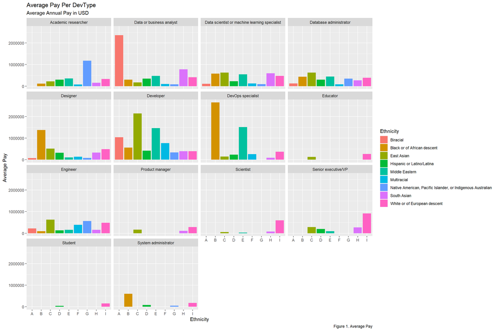

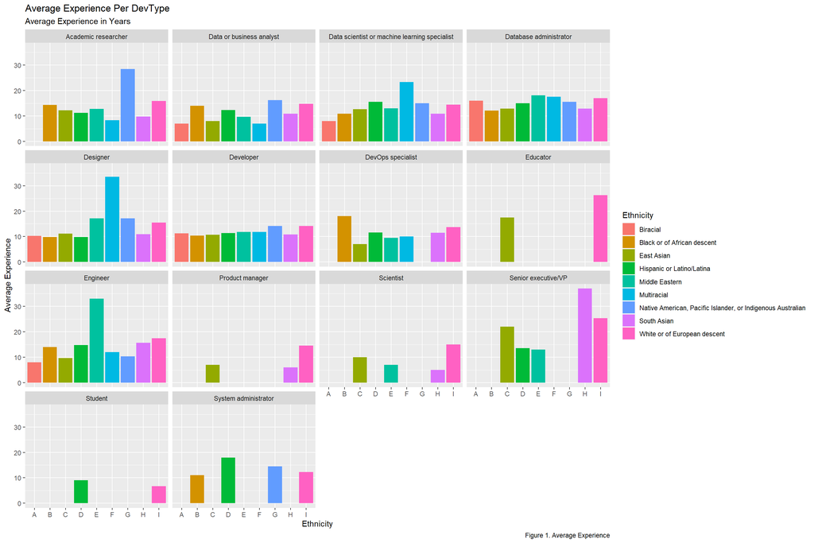

Now that I have a good understanding of my data I can begin with my Anova Analysis

# Methodology

My analysis of my data was done using the Tukey_HSD test. This test is a statistical tool used to determine if the relationship between two sets of data is statistically significant.

## Tukey Analysis

I made four models. The main model of interest would be the ‘Pay and Ethnicity Model’.

### Pay And DevType

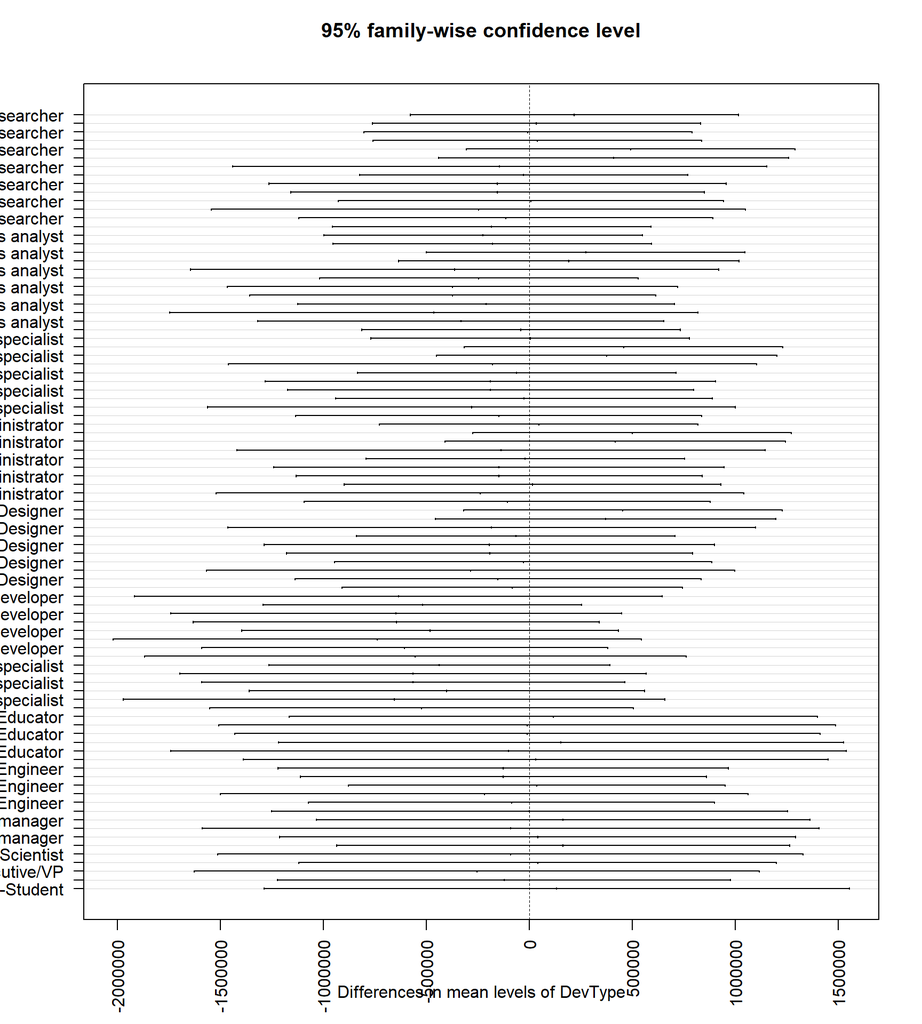

```
##             Df    Sum Sq   Mean Sq F value Pr(>F)
## DevType     13 3.591e+12 2.763e+11   1.234  0.273
## Residuals   75 1.679e+13 2.239e+11
```

Pay to DevType

|  | diff | lwr | upr | p adj |
| --- | --- | --- | --- | --- |
| Data or business analyst-Academic researcher | 217890.78 | -579047.5 | 1014829.0 | 1.00 |
| Data scientist or machine learning specialist-Academic researcher | 34210.74 | -762727.5 | 831149.0 | 1.00 |
| Database administrator-Academic researcher | -7292.23 | -804230.5 | 789646.0 | 1.00 |
| Designer-Academic researcher | 38324.24 | -758614.0 | 835262.5 | 1.00 |
| Developer-Academic researcher | 491384.46 | -305553.8 | 1288322.7 | 0.67 |
| DevOps specialist-Academic researcher | 409057.41 | -439767.4 | 1257882.2 | 0.92 |
| Educator-Academic researcher | -144911.86 | -1441513.2 | 1151689.5 | 1.00 |
| Engineer-Academic researcher | -28090.34 | -825028.6 | 768847.9 | 1.00 |
| Product manager-Academic researcher | -155514.16 | -1265857.2 | 954828.9 | 1.00 |
| Scientist-Academic researcher | -155018.36 | -1159361.5 | 849324.7 | 1.00 |
| Senior executive/VP-Academic researcher | 8214.33 | -926778.2 | 943206.9 | 1.00 |
| Student-Academic researcher | -247328.53 | -1543929.9 | 1049272.8 | 1.00 |
| System administrator-Academic researcher | -114684.48 | -1119027.6 | 889658.6 | 1.00 |
| Data scientist or machine learning specialist-Data or business analyst | -183680.04 | -956823.7 | 589463.6 | 1.00 |
| Database administrator-Data or business analyst | -225183.01 | -998326.7 | 547960.7 | 1.00 |
| Designer-Data or business analyst | -179566.54 | -952710.2 | 593577.1 | 1.00 |
| Developer-Data or business analyst | 273493.68 | -499650.0 | 1046637.3 | 0.99 |
| DevOps specialist-Data or business analyst | 191166.63 | -635358.7 | 1017692.0 | 1.00 |
| Educator-Data or business analyst | -362802.64 | -1644916.4 | 919311.1 | 1.00 |
| Engineer-Data or business analyst | -245981.12 | -1019124.8 | 527162.6 | 1.00 |
| Product manager-Data or business analyst | -373404.94 | -1466795.2 | 719985.3 | 1.00 |
| Scientist-Data or business analyst | -372909.14 | -1358477.8 | 612659.5 | 0.99 |
| Senior executive/VP-Data or business analyst | -209676.45 | -1124472.4 | 705119.5 | 1.00 |
| Student-Data or business analyst | -465219.31 | -1747333.1 | 816894.4 | 0.99 |
| System administrator-Data or business analyst | -332575.26 | -1318143.9 | 652993.4 | 1.00 |
| Database administrator-Data scientist or machine learning specialist | -41502.97 | -814646.7 | 731640.7 | 1.00 |
| Designer-Data scientist or machine learning specialist | 4113.51 | -769030.2 | 777257.2 | 1.00 |
| Developer-Data scientist or machine learning specialist | 457173.72 | -315970.0 | 1230317.4 | 0.73 |
| DevOps specialist-Data scientist or machine learning specialist | 374846.67 | -451678.7 | 1201372.0 | 0.95 |
| Educator-Data scientist or machine learning specialist | -179122.60 | -1461236.3 | 1102991.1 | 1.00 |

[output cut: 61 more lines]

### Experience and DevType

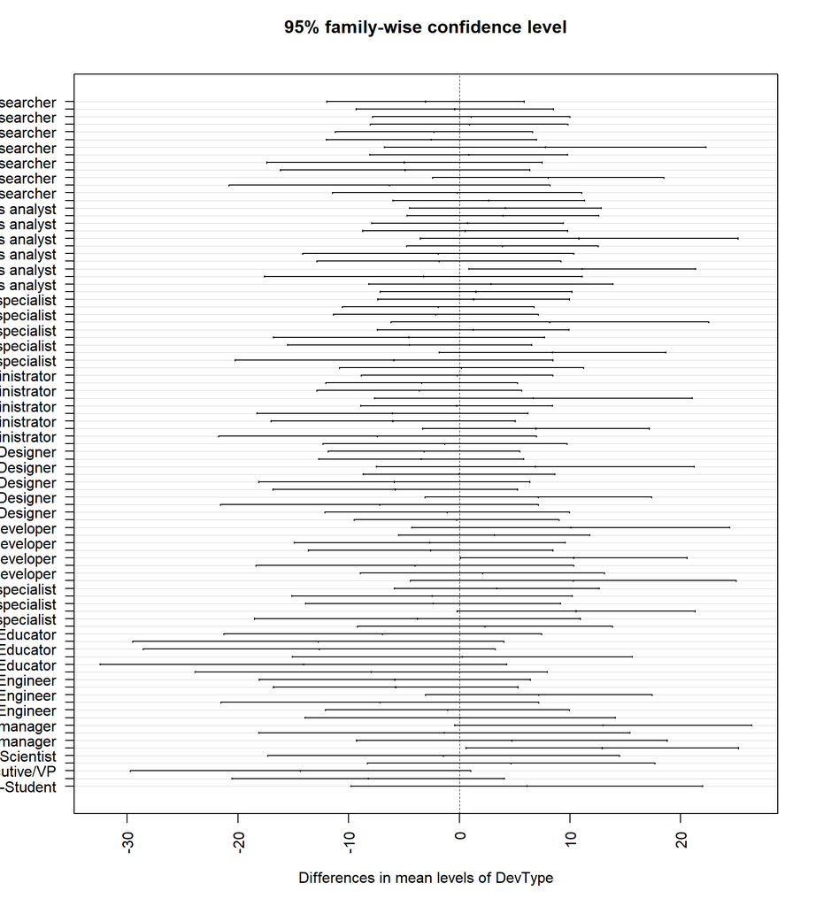

```
##             Df Sum Sq Mean Sq F value  Pr(>F)
## DevType     13  880.6   67.74   2.413 0.00893 **
## Residuals   75 2105.5   28.07
## ---
## Signif. codes:  0 '***' 0.001 '**' 0.01 '*' 0.05 '.' 0.1 ' ' 1
```

|  | diff | lwr | upr | p adj |
| --- | --- | --- | --- | --- |
| Data or business analyst-Academic researcher | -3.06 | -11.98 | 5.87 | 1.00 |
| Data scientist or machine learning specialist-Academic researcher | -0.40 | -9.32 | 8.53 | 1.00 |
| Database administrator-Academic researcher | 1.10 | -7.83 | 10.02 | 1.00 |
| Designer-Academic researcher | 0.90 | -8.03 | 9.82 | 1.00 |
| Developer-Academic researcher | -2.30 | -11.22 | 6.63 | 1.00 |
| DevOps specialist-Academic researcher | -2.52 | -12.03 | 6.98 | 1.00 |
| Educator-Academic researcher | 7.77 | -6.74 | 22.29 | 0.84 |
| Engineer-Academic researcher | 0.86 | -8.07 | 9.78 | 1.00 |
| Product manager-Academic researcher | -4.96 | -17.39 | 7.47 | 0.98 |
| Scientist-Academic researcher | -4.88 | -16.13 | 6.36 | 0.96 |
| Senior executive/VP-Academic researcher | 8.04 | -2.43 | 18.51 | 0.32 |
| Student-Academic researcher | -6.30 | -20.82 | 8.22 | 0.96 |
| System administrator-Academic researcher | -0.20 | -11.44 | 11.05 | 1.00 |
| Data scientist or machine learning specialist-Data or business analyst | 2.66 | -6.00 | 11.32 | 1.00 |
| Database administrator-Data or business analyst | 4.15 | -4.50 | 12.81 | 0.92 |
| Designer-Data or business analyst | 3.96 | -4.70 | 12.61 | 0.95 |
| Developer-Data or business analyst | 0.76 | -7.90 | 9.42 | 1.00 |
| DevOps specialist-Data or business analyst | 0.53 | -8.72 | 9.79 | 1.00 |
| Educator-Data or business analyst | 10.83 | -3.52 | 25.19 | 0.35 |
| Engineer-Data or business analyst | 3.92 | -4.74 | 12.57 | 0.95 |
| Product manager-Data or business analyst | -1.90 | -14.15 | 10.34 | 1.00 |
| Scientist-Data or business analyst | -1.83 | -12.86 | 9.21 | 1.00 |
| Senior executive/VP-Data or business analyst | 11.10 | 0.85 | 21.34 | 0.02 |
| Student-Data or business analyst | -3.24 | -17.60 | 11.11 | 1.00 |
| System administrator-Data or business analyst | 2.86 | -8.18 | 13.90 | 1.00 |
| Database administrator-Data scientist or machine learning specialist | 1.49 | -7.16 | 10.15 | 1.00 |
| Designer-Data scientist or machine learning specialist | 1.30 | -7.36 | 9.95 | 1.00 |
| Developer-Data scientist or machine learning specialist | -1.90 | -10.56 | 6.76 | 1.00 |
| DevOps specialist-Data scientist or machine learning specialist | -2.13 | -11.38 | 7.13 | 1.00 |
| Educator-Data scientist or machine learning specialist | 8.17 | -6.18 | 22.53 | 0.78 |

[output cut: 61 more lines]

### Pay and Ethnicity

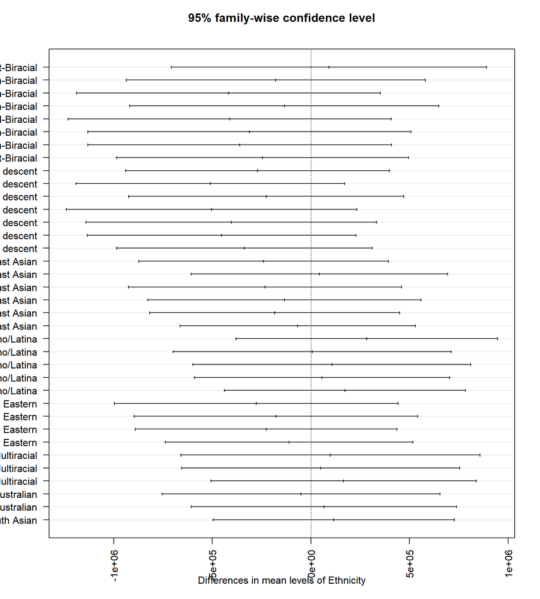

```
##             Df    Sum Sq   Mean Sq F value Pr(>F)
## Ethnicity    8 2.269e+12 2.836e+11   1.253   0.28
## Residuals   80 1.811e+13 2.264e+11
```

|  | diff | lwr | upr | p adj |
| --- | --- | --- | --- | --- |
| Black or of African descent-Biracial | 91783.48 | -707814.5 | 891381.5 | 1.00 |
| East Asian-Biracial | -178128.07 | -936693.3 | 580437.2 | 1.00 |
| Hispanic or Latino/Latina-Biracial | -417769.46 | -1187742.4 | 352203.5 | 0.73 |
| Middle Eastern-Biracial | -134452.84 | -917895.7 | 648990.0 | 1.00 |
| Multiracial-Biracial | -411143.76 | -1230487.9 | 408200.4 | 0.80 |
| Native American, Pacific Islander, or Indigenous Australian-Biracial | -311661.71 | -1131005.9 | 507682.4 | 0.95 |
| South Asian-Biracial | -361224.18 | -1131197.1 | 408748.7 | 0.85 |
| White or of European descent-Biracial | -244984.84 | -985268.8 | 495299.1 | 0.98 |
| East Asian-Black or of African descent | -269911.54 | -938903.2 | 399080.2 | 0.93 |
| Hispanic or Latino/Latina-Black or of African descent | -509552.94 | -1191452.4 | 172346.5 | 0.31 |
| Middle Eastern-Black or of African descent | -226236.32 | -923309.7 | 470837.1 | 0.98 |
| Multiracial-Black or of African descent | -502927.23 | -1240120.2 | 234265.7 | 0.43 |
| Native American, Pacific Islander, or Indigenous Australian-Black or of African descent | -403445.18 | -1140638.1 | 333747.8 | 0.72 |
| South Asian-Black or of African descent | -453007.66 | -1134907.1 | 228891.8 | 0.47 |
| White or of European descent-Black or of African descent | -336768.31 | -984957.2 | 311420.6 | 0.77 |
| Hispanic or Latino/Latina-East Asian | -239641.40 | -872927.4 | 393644.6 | 0.95 |
| Middle Eastern-East Asian | 43675.23 | -605921.3 | 693271.7 | 1.00 |
| Multiracial-East Asian | -233015.69 | -925487.9 | 459456.5 | 0.98 |
| Native American, Pacific Islander, or Indigenous Australian-East Asian | -133533.64 | -826005.8 | 558938.6 | 1.00 |
| South Asian-East Asian | -183096.11 | -816382.1 | 450189.9 | 0.99 |
| White or of European descent-East Asian | -66856.77 | -663692.7 | 529979.2 | 1.00 |
| Middle Eastern-Hispanic or Latino/Latina | 283316.62 | -379565.4 | 946198.7 | 0.91 |
| Multiracial-Hispanic or Latino/Latina | 6625.71 | -698324.5 | 711575.9 | 1.00 |
| Native American, Pacific Islander, or Indigenous Australian-Hispanic or Latino/Latina | 106107.76 | -598842.4 | 811057.9 | 1.00 |
| South Asian-Hispanic or Latino/Latina | 56545.29 | -590361.4 | 703451.9 | 1.00 |
| White or of European descent-Hispanic or Latino/Latina | 172784.63 | -438484.7 | 784053.9 | 0.99 |
| Multiracial-Middle Eastern | -276690.92 | -996329.1 | 442947.3 | 0.95 |
| Native American, Pacific Islander, or Indigenous Australian-Middle Eastern | -177208.87 | -896847.1 | 542429.3 | 1.00 |
| South Asian-Middle Eastern | -226771.34 | -889653.4 | 436110.7 | 0.97 |
| White or of European descent-Middle Eastern | -110532.00 | -738683.7 | 517619.7 | 1.00 |
| Native American, Pacific Islander, or Indigenous Australian-Multiracial | 99482.05 | -659083.2 | 858047.3 | 1.00 |
| South Asian-Multiracial | 49919.58 | -655030.6 | 754869.8 | 1.00 |
| White or of European descent-Multiracial | 166158.92 | -506237.3 | 838555.2 | 1.00 |
| South Asian-Native American, Pacific Islander, or Indigenous Australian | -49562.47 | -754512.6 | 655387.7 | 1.00 |
| White or of European descent-Native American, Pacific Islander, or Indigenous Australian | 66676.87 | -605719.4 | 739073.1 | 1.00 |
| White or of European descent-South Asian | 116239.34 | -495030.0 | 727508.7 | 1.00 |